# mohamedsaed93: Traffic Data Analysis

```r
library(ggplot2)
library(dplyr)
library(reshape)
library(reshape2)
library(tidyr)
library(knitr)
library(plyr)
library(BSDA)
library(stringr)
```

# Data Processing : identify metrics and dimensions

## First of all importing the data into R

```r
by2olak_data = read.csv("all-semi-unique.csv")
str(lapply(by2olak_data, unique), vec.len = 4)
```

```
## List of 34
##  $ crawl_date     : Factor w/ 28331 levels "Fri Feb 12 00:00:14 UTC 2016",..: 1869 8758 8809 8862 8916 8966 9022 9147 9212 9271 ...
##  $ ad.aid         : int 2538
##  $ ad.bgcl        : Factor w/ 1 level "#003768": 1
##  $ ad.bgcls       : Factor w/ 1 level "#0069aa": 1
##  $ ad.fncl        : Factor w/ 1 level "#FFFFFF": 1
##  $ ad.fncls       : Factor w/ 1 level "#FFFFFF": 1
##  $ ad.lid         : int 1001
##  $ ad.logo        : Factor w/ 1 level "http://www.bey2ollak.com/downloads/logos/Pepsi_SA7EL.png": 1
##  $ ad.logo2x      : Factor w/ 1 level "http://www.bey2ollak.com/downloads/logos/Pepsi_SA7EL@2x.png": 1
##  $ ad.logoAndroidS: Factor w/ 1 level "http://www.bey2ollak.com/downloads/logos/Pepsi_SA7EL_ANDROID_S.png": 1
##  $ ad.logoAndroidH: Factor w/ 1 level "http://www.bey2ollak.com/downloads/logos/Pepsi_SA7EL_ANDROID_H.png": 1
##  $ ad.cm          : Factor w/ 1 level "دوس هنا وشوف إعلان بيبسي الجديد مع محمد صلاح #يلا_تقدر": 1
##  $ ad.url         : Factor w/ 1 level "http://youtu.be/aNeqShdgupY": 1
##  $ ad.g           : int 1
```

[output cut: 20 more lines]

## Removal of all the columns related to advertisements

```r
by2olak_data = subset(by2olak_data, select=-c(ad.aid,ad.bgcl,ad.bgcls,ad.fncl,ad.fncls,ad.lid,ad.logo,
    ad.logo2x,ad.logoAndroidS,ad.logoAndroidH,ad.cm,ad.url,ad.g))
```

## Removal of columns with constant values

To get a quick idea of the data, a possible way is to get the number of unique values for each column

```r
data_view <- as.data.frame(rapply(by2olak_data, function(x) length(unique(x))))
kable(rename(data_view, c("rapply(by2olak_data, function(x) length(unique(x)))"="Number of Unique Values")))
```

|  | Number of Unique Values |
| --- | --- |
| crawl_date | 28331 |
| rd.nm | 301 |
| rd.ri | 305 |
| rd.stid | 11 |
| rd.hr | 71 |
| rd.mn | 61 |
| rd.new | 2 |
| rd.img | 2 |
| rd.cl | 1 |
| rd.strq | 2 |
| rd.cmrq | 2 |
| rd.rp.nm | 16759 |
| rd.rp.fullnm | 14115 |
| rd.rp.hr | 93 |
| rd.rp.mn | 60 |
| rd.rp.stid | 11 |
| rd.rp.cm | 44716 |
| rd.rp.cmid | 148367 |
| rd.rp.rpImg | 6277 |
| rd.rp.img | 6660 |
| rd.rp.type | 1 |

### Unique values in rd.cl column

```r
unique(by2olak_data['rd.cl'])
```

```
##     rd.cl
## 1 #E6E6E6
```

There is only one value so the column can be removed.

```r
by2olak_data <- subset( by2olak_data, select = -rd.cl)
```

### Unique values in rd.rp.type column

```r
unique(by2olak_data['rd.rp.type'])
```

```
##   rd.rp.type
## 1          0
```

Same thing like rd.cl, there is only one value which is zero so it can be removed.

```r
by2olak_data <- subset(by2olak_data, select = -rd.rp.type)
```

## Working with NAs

The Date is a little bit better than before

```r
glimpse(by2olak_data)
```

```
## Observations: 429,982
## Variables: 19
## $ crawl_date   (fctr) Fri Feb  5 17:23:57 UTC 2016, Fri Feb  5 17:23:5...
## $ rd.nm        (fctr) Makram 3ebeid;Autostrad To Mostafa ElNa7as, Makr...
## $ rd.ri        (int) 678, 678, 678, 678, 678, 678, 678, 678, 678, 678,...
## $ rd.stid      (int) 3, 3, 3, 3, NA, NA, NA, NA, NA, NA, 2, 2, 2, 2, 2...
## $ rd.hr        (int) 1, 1, 1, 1, 9, 9, 9, 9, 10, 10, 0, 0, 1, 0, 1, 1,...
## $ rd.mn        (int) 12, 12, 12, 12, 5, 5, 35, 35, 5, 5, 21, 51, 21, 4...
## $ rd.new       (int) 1, 1, 1, 1, 1, 1, 1, 1, 1, 1, 1, 1, 1, 1, 1, 1, 1...
## $ rd.img       (lgl) NA, NA, NA, NA, NA, NA, NA, NA, NA, NA, NA, NA, N...
## $ rd.strq      (int) 1, 1, 1, 1, 1, 1, 1, 1, 1, 1, 1, 1, 1, 1, 1, 1, 1...
## $ rd.cmrq      (int) 0, 0, 0, 0, 0, 0, 0, 0, 0, 0, 0, 0, 0, 0, 0, 0, 0...
## $ rd.rp.nm     (fctr) Tahany_Eyad, 7abeba_Sa3d, fa3el kheir, ShahinazS...
## $ rd.rp.fullnm (fctr) Tahany Eyad, 7abeba Sa3d, NA, Shahinaz Sale7, Ga...
## $ rd.rp.hr     (int) 18, 20, 22, 23, 23, 28, 24, 29, 24, 29, 23, 23, 2...
## $ rd.rp.mn     (int) 38, 26, 6, 47, 32, 56, 2, 26, 32, 56, 5, 35, 5, 1...
## $ rd.rp.stid   (int) 2, 2, 2, 2, 2, 1, 2, 1, 2, 1, 2, 2, 2, 2, 2, 2, 3...
## $ rd.rp.cm     (fctr) lazeez, lazeez, lazeez, lazeez, lazeez, 7alawa, ...
## $ rd.rp.cmid   (int) 9300046, 9299640, 9299068, 9298351, 9300548, 9300...
## $ rd.rp.rpImg  (int) NA, NA, NA, NA, NA, NA, NA, NA, NA, NA, NA, NA, N...
## $ rd.rp.img    (int) NA, NA, NA, NA, NA, 842, NA, 842, NA, 842, NA, NA...
```

### Unique values in rd.img column

```r
kable(as.data.frame(unique(by2olak_data['rd.img'])))
```

|  | rd.img |
| --- | --- |
| 1 | NA |
| 567 | TRUE |

It is obvious that NA corresponds to no image which simply can be false.

```r
by2olak_data <- by2olak_data %>% mutate(rd.img = ifelse(is.na(rd.img),FALSE,rd.img))
```

### Removal of User full name column

The 2 columns rd.rp.fullnm & rd.rp.nm are similar from the values of the 2 columns as one is the username and the other is the full name of the user which is not very useful

We can check the number of NAs in each of them

```r
sum(is.na(by2olak_data['rd.rp.fullnm']))
```

```
## [1] 52055
```

```r
sum(is.na(by2olak_data['rd.rp.nm']))
```

```
## [1] 0
```

It is possible to remove rd.rp.fullnm as it has a lot of NAs and the column does not provide any additional information

```r
by2olak_data <- subset( by2olak_data, select = -rd.rp.fullnm)
```

At this point, it is useful to see the number of NAs in each column:

```r
data_view <- as.data.frame(rapply(subset(by2olak_data, select = c(rd.rp.rpImg,rd.rp.img)), function(x) sum(is.na(x))))
kable(rename(data_view, c("rapply(subset(by2olak_data, select = c(rd.rp.rpImg, rd.rp.img)), function(x) sum(is.na(x)))"="Number of NAs")))
```

|  | Number of NAs |
| --- | --- |
| rd.rp.rpImg | 411585 |
| rd.rp.img | 152557 |

### Default Values for Road and Report images

A lot of NAs are there in rd.rp.rpImg & rd.rp.img so we can add a default value for these NAs which could be zero but first we have to make sure zero is not a value in these columns.

```r
data_view <- as.data.frame(rapply(subset(by2olak_data, select = c(rd.rp.rpImg,rd.rp.img)), function(x) sum(x == 0 | is.na(x))))
kable(rename(data_view, c("rapply(subset(by2olak_data, select = c(rd.rp.rpImg, rd.rp.img)), function(x) sum(x == 0 | is.na(x)))"="Number of NAs or Zero Values")))
```

|  | Number of NAs or Zero Values |
| --- | --- |
| rd.rp.rpImg | 411585 |
| rd.rp.img | 152557 |

Since the number is the same for NAs and for NAs or zeros. We can conclude there are no zero values so it can be used as a default value

```r
by2olak_data <- by2olak_data %>% mutate(rd.rp.rpImg = ifelse(is.na(rd.rp.rpImg),0,rd.rp.rpImg))
by2olak_data <- by2olak_data %>% mutate(rd.rp.img = ifelse(is.na(rd.rp.img),0,rd.rp.img))
```

Let’s see now the number of NAs in each column after cleaning the data.

```r
data_view <- as.data.frame(rapply(by2olak_data, function(x) sum(is.na(x))))
kable(rename(data_view, c("rapply(by2olak_data, function(x) sum(is.na(x)))"="Number of NAs")))
```

|  | Number of NAs |
| --- | --- |
| crawl_date | 0 |
| rd.nm | 0 |
| rd.ri | 0 |
| rd.stid | 30100 |
| rd.hr | 1507 |
| rd.mn | 1507 |
| rd.new | 0 |
| rd.img | 0 |
| rd.strq | 0 |
| rd.cmrq | 0 |
| rd.rp.nm | 0 |
| rd.rp.hr | 0 |
| rd.rp.mn | 0 |
| rd.rp.stid | 13965 |
| rd.rp.cm | 0 |
| rd.rp.cmid | 0 |
| rd.rp.rpImg | 0 |
| rd.rp.img | 0 |

There are still Columns with NAs, the rd.rp.stid with NAs is actually comments or questioning info for the road. A value should be given for such a scenario, let’s have a look at the values of this column

```r
kable(as.data.frame(table(by2olak_data['rd.rp.stid'])))
```

| Var1 | Freq |
| --- | --- |
| 1 | 46552 |
| 2 | 127614 |
| 3 | 41545 |
| 4 | 33556 |
| 5 | 25620 |
| 6 | 33996 |
| 7 | 875 |
| 8 | 711 |
| 9 | 397 |
| 10 | 105151 |

0 for example is a possible value to be used as they are all from 1 to 10.

```r
by2olak_data$rd.rp.stid[is.na(by2olak_data$rd.rp.stid)] <- 0
```

The NAs for the columns after adjustments

```r
data_view <- as.data.frame(rapply(by2olak_data, function(x) sum(is.na(x))))
kable(rename(data_view, c("rapply(by2olak_data, function(x) sum(is.na(x)))"="Number of NAs")))
```

|  | Number of NAs |
| --- | --- |
| crawl_date | 0 |
| rd.nm | 0 |
| rd.ri | 0 |
| rd.stid | 30100 |
| rd.hr | 1507 |
| rd.mn | 1507 |
| rd.new | 0 |
| rd.img | 0 |
| rd.strq | 0 |
| rd.cmrq | 0 |
| rd.rp.nm | 0 |
| rd.rp.hr | 0 |
| rd.rp.mn | 0 |
| rd.rp.stid | 0 |
| rd.rp.cm | 0 |
| rd.rp.cmid | 0 |
| rd.rp.rpImg | 0 |
| rd.rp.img | 0 |

For hours and mins of road rd.hr & rd.mn, their NAs can be removed as they are 1507 from all rows, which can be neglected.

```r
by2olak_data <- by2olak_data[!is.na(by2olak_data$rd.hr),]
by2olak_data <- by2olak_data[!is.na(by2olak_data$rd.mn),]
```

Now the only column which contains NAs is rd.stid

```r
sum(is.na(by2olak_data['rd.stid']))
```

```
## [1] 29667
```

```r
by2olak_data <- na.omit(by2olak_data)
```

Now all the columns have no NAs as a value

```r
data_view <- as.data.frame(rapply(by2olak_data, function(x) sum(is.na(x))))
kable(rename(data_view, c("rapply(by2olak_data, function(x) sum(is.na(x)))"="Number of NAs")))
```

|  | Number of NAs |
| --- | --- |
| crawl_date | 0 |
| rd.nm | 0 |
| rd.ri | 0 |
| rd.stid | 0 |
| rd.hr | 0 |
| rd.mn | 0 |
| rd.new | 0 |
| rd.img | 0 |
| rd.strq | 0 |
| rd.cmrq | 0 |
| rd.rp.nm | 0 |
| rd.rp.hr | 0 |
| rd.rp.mn | 0 |
| rd.rp.stid | 0 |
| rd.rp.cm | 0 |
| rd.rp.cmid | 0 |
| rd.rp.rpImg | 0 |
| rd.rp.img | 0 |

## Formatting the Crawl Date

To extract the day itself from data (Sun, Tue, etc.)

```r
by2olak_data$day <- gsub("([A-Za-z]+).*", "\\1", by2olak_data$crawl_date)
head(by2olak_data$day)
```

```
## [1] "Fri" "Fri" "Fri" "Fri" "Sat" "Sat"
```

The crawl_date is the date when this data was crawled in UTC which is 2 hours behind Cairo time), The crawl date will be adjusted to be synchronized with Cairo time (GMT+2)

In the R code it will be GMT-2 as the time was behind by 2 hours (-2)

```r
by2olak_data$crawl_date <- strptime(by2olak_data$crawl_date, format = "%a %b %d %X UTC %Y", tz = "UTC") %>% as.POSIXct()
by2olak_data$crawl_date <- format(by2olak_data$crawl_date , "%Y-%m-%d-%H-%M-%S", tz="Etc/GMT-2")
head(by2olak_data$crawl_date)
```

```
## [1] "2016-02-05-19-23-57" "2016-02-05-19-23-57" "2016-02-05-19-23-57"
## [4] "2016-02-05-19-23-57" "2016-02-06-11-31-02" "2016-02-06-12-01-00"
```

To modify the day to be Sunday, Tuesday instead of Sun,Tue, etc.

```r
by2olak_data <- by2olak_data %>% mutate(day = weekdays(as.Date(by2olak_data$crawl_date)))
head(by2olak_data$day)
```

```
## [1] "Friday"   "Friday"   "Friday"   "Friday"   "Saturday" "Saturday"
```

Since the Crawl day is not necessarily the day of the report, calculation of the actual day should be done.

```r
by2olak_data <- by2olak_data %>% mutate(actual_day =
    ifelse(by2olak_data$rd.hr < 24, weekdays(as.Date(by2olak_data$crawl_date)),
        ifelse(by2olak_data$rd.hr >= 24 & by2olak_data$rd.hr<= 48,weekdays(as.Date(by2olak_data$crawl_date)+1),
        weekdays(as.Date(by2olak_data$crawl_date)+2))))
data_sample <- by2olak_data[sample(nrow(by2olak_data), 10), ]
kable(data_sample[,c('day','actual_day','rd.hr')])
```

|  | day | actual_day | rd.hr |
| --- | --- | --- | --- |
| 388562 | Tuesday | Tuesday | 0 |
| 188440 | Sunday | Sunday | 0 |
| 429951 | Sunday | Sunday | 0 |
| 104444 | Sunday | Sunday | 0 |
| 5754 | Monday | Monday | 0 |
| 361062 | Wednesday | Wednesday | 0 |
| 285251 | Tuesday | Tuesday | 1 |
| 51942 | Wednesday | Wednesday | 1 |
| 196957 | Monday | Monday | 0 |
| 272043 | Sunday | Sunday | 0 |

## Additional Columns for adding features

### Splitting the road name into road header and road start and road destination

Create columns that split the road name into 2 in which one is the road header and the other one is the path_taken

```r
by2olak_data <- by2olak_data %>% separate(rd.nm, c("road_header", "road_path_taken"), ";")
```

Now let’s split the road_path_taken into 2 columns from and to columns

```r
by2olak_data <- by2olak_data %>% separate(road_path_taken, c("road_start", "road_destination"), " To ")
```

Let’s see the NAs in the new columns

```r
sum(is.na(by2olak_data['road_header']))
```

```
## [1] 0
```

```r
sum(is.na(by2olak_data['road_start']))
```

```
## [1] 12238
```

```r
sum(is.na(by2olak_data['road_destination']))
```

```
## [1] 12238
```

There are NAs in road_start and road_destination as some roads have only header. Default values should replace the NAs.

```r
by2olak_data$road_start[is.na(by2olak_data$road_start)] <- "NONE"
by2olak_data$road_destination[is.na(by2olak_data$road_destination)] <- "NONE"
```

### Creating a column to show the reports origin : Automated or not

```r
by2olak_data['gps'] <- (by2olak_data['rd.rp.nm'] == "bey2ollakgps")
```

### Creating a column to show if the reports are from Anonymous Users.

```r
by2olak_data['anonymous'] <- (by2olak_data['rd.rp.nm'] == "fa3el kheir")
```

### Creating a column to distinguish between day and night in the data.

The Night is considered from 9 pm to 6 am (After Work and Rush hours) 2 are subtracted from the hours to get the proper time in Cairo time-zone

```r
by2olak_data$time_hours <- format(as.POSIXct(by2olak_data$crawl_date, format="%Y-%m-%d-%H-%M-%S"), format="%H")
by2olak_data$time_hours <- as.numeric(by2olak_data$time_hours, units = "hours")
by2olak_data <- by2olak_data %>% mutate(time_hours = ifelse(by2olak_data$time_hours < 0,
    as.numeric(by2olak_data$time_hours, units = "hours") + 12,
    as.numeric(by2olak_data$time_hours, units = "hours")))
by2olak_data <- by2olak_data %>% mutate(day_night = ifelse(by2olak_data$time_hours < 6 | by2olak_data$time_hours>= 21 , "NIGHT", "DAY"))
```

### Obtaining the Speed of roads from the automated reports by the GPS.

```r
by2olak_data$speed <- str_extract(by2olak_data$rd.rp.cm, "([0-9]+ km/h)|[0-9]+ كم/س")
by2olak_data$speed <- str_extract(by2olak_data$speed, "([0-9]+)")
by2olak_data <- by2olak_data %>% mutate(speed = ifelse(is.na(speed),-1,speed))
by2olak_data$speed <- as.numeric(by2olak_data$speed)
```

## Reordering columns

```r
colnames(by2olak_data)
```

```
##  [1] "crawl_date"       "road_header"      "road_start"
##  [4] "road_destination" "rd.ri"            "rd.stid"
##  [7] "rd.hr"            "rd.mn"            "rd.new"
## [10] "rd.img"           "rd.strq"          "rd.cmrq"
## [13] "rd.rp.nm"         "rd.rp.hr"         "rd.rp.mn"
## [16] "rd.rp.stid"       "rd.rp.cm"         "rd.rp.cmid"
## [19] "rd.rp.rpImg"      "rd.rp.img"        "day"
## [22] "actual_day"       "gps"              "anonymous"
## [25] "time_hours"       "day_night"        "speed"
```

The columns are not in order anymore, it can be fixed by specifying the order we want.

```r
by2olak_data <- subset(by2olak_data, select=c(crawl_date,day,actual_day,time_hours,day_night,road_header,road_start,road_destination,rd.ri,
    rd.stid,rd.hr,rd.mn,rd.new,rd.img,rd.strq,rd.cmrq,rd.rp.nm,gps,anonymous,rd.rp.hr,
    rd.rp.mn,rd.rp.stid,rd.rp.cm,rd.rp.cmid,speed,rd.rp.rpImg,rd.rp.img))
colnames(by2olak_data)
```

```
##  [1] "crawl_date"       "day"              "actual_day"
##  [4] "time_hours"       "day_night"        "road_header"
##  [7] "road_start"       "road_destination" "rd.ri"
## [10] "rd.stid"          "rd.hr"            "rd.mn"
## [13] "rd.new"           "rd.img"           "rd.strq"
## [16] "rd.cmrq"          "rd.rp.nm"         "gps"
## [19] "anonymous"        "rd.rp.hr"         "rd.rp.mn"
## [22] "rd.rp.stid"       "rd.rp.cm"         "rd.rp.cmid"
## [25] "speed"            "rd.rp.rpImg"      "rd.rp.img"
```

## Removal of columns related to by2ollak application for processing and does not affect the data

```r
by2olak_data = subset(by2olak_data, select=-c(rd.new,rd.strq,rd.cmrq))
```

## Renaming the columns to give them a proper meaning

```r
by2olak_data <- rename(by2olak_data, c("rd.ri"="road_route_id","rd.stid"="road_status_id",
 "rd.hr"="road_update_hours_ago","rd.mn"="road_update_mins_ago", "rd.img"="road_image", "rd.rp.nm"="report_username", "rd.rp.hr"="report_update_hours_ago", "rd.rp.mn"="report_update_mins_ago",
 "rd.rp.stid"="report_status_id" , "rd.rp.cm"="report_comment", "rd.rp.cmid"="report_comment_id" ,
 "rd.rp.rpImg"="report_roadimage" , "rd.rp.img"="report_username_image"))
colnames(by2olak_data)
```

```
##  [1] "crawl_date"              "day"
##  [3] "actual_day"              "time_hours"
##  [5] "day_night"               "road_header"
##  [7] "road_start"              "road_destination"
##  [9] "road_route_id"           "road_status_id"
## [11] "road_update_hours_ago"   "road_update_mins_ago"
## [13] "road_image"              "report_username"
## [15] "gps"                     "anonymous"
## [17] "report_update_hours_ago" "report_update_mins_ago"
## [19] "report_status_id"        "report_comment"
## [21] "report_comment_id"       "speed"
## [23] "report_roadimage"        "report_username_image"
```

## Finally Removal of rows with same comment id

```r
by2olak_data <- by2olak_data[!duplicated(by2olak_data$report_comment_id),]
```

```r
summary(by2olak_data)
```

[output not shown]

# Descriptive Statistics to investigate the metrics and dimensions.

## Summary Statistics

### Envolvement of Users in the reports :

There are two types of reports (reports by users and automated ones). For the reports submitted by users, the user can report as “fa3el kheir” which becomes anonymous to by2ollak.

Here are the numbers or automated reports, anonymous ones and finally reports in which the reporter is not anonymous.

```r
nrow(by2olak_data[by2olak_data$gps,])
```

```
## [1] 57596
```

```r
nrow(by2olak_data[by2olak_data$anonymous,])
```

```
## [1] 13354
```

```r
nrow(by2olak_data[by2olak_data$anonymous == FALSE & by2olak_data$gps== FALSE,])
```

```
## [1] 69554
```

For the above results, it is clear that the reports from users are a lot more that the automated ones, although there is a portion of users that report anonymously.

### Measures of central tendency and spread

At this point, It is known that the status of by2ollak is organised as follows

| status_id | meaning |
| --- | --- |
| 1 | 7alawa |
| 2 | lazeez |
| 3 | mashy |
| 4 | za7ma |
| 5 | mafesh amal |
| 6 | so2al |
| 7 | khatar |
| 8 | 7adsa |
| 9 | 3otl |
| 10 | ba2ollak eh |

```r
by2olak_data_proper_status <- by2olak_data[by2olak_data$road_status_id <= 5,]
by2olak_data_proper_status <- by2olak_data_proper_status[by2olak_data_proper_status$report_status_id <= 5,]
```

### Roads status for each day from 1 to 5 in order

```r
filtered_data <- count(by2olak_data_proper_status, c("actual_day", "road_status_id"))
kable(as.data.frame(table(by2olak_data_proper_status$road_status_id, by2olak_data_proper_status$actual_day)))
```

| Var1 | Var2 | Freq |
| --- | --- | --- |
| 1 | Friday | 880 |
| 2 | Friday | 3350 |
| 3 | Friday | 613 |
| 4 | Friday | 183 |
| 5 | Friday | 149 |
| 1 | Monday | 893 |
| 2 | Monday | 4359 |
| 3 | Monday | 599 |
| 4 | Monday | 605 |
| 5 | Monday | 256 |
| 1 | Saturday | 1380 |
| 2 | Saturday | 3825 |
| 3 | Saturday | 905 |
| 4 | Saturday | 582 |
| 5 | Saturday | 277 |
| 1 | Sunday | 1618 |
| 2 | Sunday | 4588 |
| 3 | Sunday | 1290 |
| 4 | Sunday | 695 |
| 5 | Sunday | 472 |
| 1 | Thursday | 1124 |
| 2 | Thursday | 4161 |
| 3 | Thursday | 616 |
| 4 | Thursday | 388 |
| 5 | Thursday | 244 |
| 1 | Tuesday | 1341 |
| 2 | Tuesday | 3979 |
| 3 | Tuesday | 1273 |
| 4 | Tuesday | 883 |
| 5 | Tuesday | 377 |
| 1 | Wednesday | 1361 |
| 2 | Wednesday | 3600 |
| 3 | Wednesday | 1142 |
| 4 | Wednesday | 726 |
| 5 | Wednesday | 392 |

### Districts with highest activity.

```r
filtered_data <- count(by2olak_data_proper_status, c("road_header"))
kable(head(filtered_data [with(filtered_data , order(desc(freq))),]))
```

|  | road_header | freq |
| --- | --- | --- |
| 15 | Da2ery | 6383 |
| 67 | Me7war | 4992 |
| 90 | Sa7rawy | 2736 |
| 92 | Sala7 Salem | 1878 |
| 10 | Autostrad | 1826 |
| 122 | Zera3y Road | 1805 |

Now let’s calculate the mean, median and mode for the important columns which are the road_status_id, report_status_id, road_update_hours_ago and report_update_hours_ago

First let’s implement the function that will compute the mode as it is not implemented in R

```r
estimate_mode <- function(x) {
    d <- density(x)
     d$x[which.max(d$y)]
 }
```

### Mean - Median - Mode

All of these are ways to describe the average or the central point of the data

### Standard deviation

expresses by how much the values differ from the mean value(there is the 68–95–99.7 rule) which is a shorthand to remember the percentage of values that lie within a band around the mean in a normal distribution with a width of one, two and three standard deviations, respectively; more accurately, 68.27%, 95.45% and 99.73% of the value

### Variance

shows how the data is different, divergent, or inconsistent.

Now let’s compute them for the important columns

#### Road Status Id

```r
mean(by2olak_data_proper_status$road_status_id)
```

```
## [1] 2.253756
```

```r
median(by2olak_data_proper_status$road_status_id)
```

```
## [1] 2
```

```r
estimate_mode(by2olak_data_proper_status$road_status_id)
```

```
## [1] 1.999628
```

```r
sd(by2olak_data_proper_status$road_status_id)
```

```
## [1] 0.9845905
```

```r
var(by2olak_data_proper_status$road_status_id)
```

```
## [1] 0.9694185
```

#### Report Status Id

```r
mean(by2olak_data_proper_status$report_status_id)
```

```
## [1] 2.390079
```

```r
median(by2olak_data_proper_status$report_status_id)
```

```
## [1] 2
```

```r
estimate_mode(by2olak_data_proper_status$report_status_id)
```

```
## [1] 2.002737
```

```r
sd(by2olak_data_proper_status$report_status_id)
```

```
## [1] 1.193604
```

```r
var(by2olak_data_proper_status$report_status_id)
```

```
## [1] 1.424691
```

It is clear that the median of road status id and report status id are equal, this is due to the fact that the road status id is actually calculated based on the reports status ids for the road at the time of the request, so the road status id and the report status id are positively correlated.

```r
kable(as.data.frame(cor(by2olak_data[c("road_status_id","report_status_id")])))
```

|  | road_status_id | report_status_id |
| --- | --- | --- |
| road_status_id | 1.0000000 | 0.3804352 |
| report_status_id | 0.3804352 | 1.0000000 |

#### Road Update Hours ago

```r
mean(by2olak_data_proper_status$road_update_hours_ago)
```

```
## [1] 0.1255954
```

```r
median(by2olak_data_proper_status$road_update_hours_ago)
```

```
## [1] 0
```

```r
estimate_mode(by2olak_data_proper_status$road_update_hours_ago)
```

```
## [1] 0.000723254
```

```r
sd(by2olak_data_proper_status$road_update_hours_ago)
```

```
## [1] 0.3313962
```

```r
var(by2olak_data_proper_status$road_update_hours_ago)
```

```
## [1] 0.1098234
```

All the values approach zero which indicates that the status of the roads are updated regularly and that the data are centered around the mean as the variance is nearly equal to zero.

#### Report Update Hours ago

```r
mean(by2olak_data_proper_status$report_update_hours_ago)
```

```
## [1] 10.83905
```

```r
median(by2olak_data_proper_status$report_update_hours_ago)
```

```
## [1] 9
```

```r
estimate_mode(by2olak_data_proper_status$report_update_hours_ago)
```

```
## [1] 22.9336
```

```r
sd(by2olak_data_proper_status$report_update_hours_ago)
```

```
## [1] 8.365114
```

```r
var(by2olak_data_proper_status$report_update_hours_ago)
```

```
## [1] 69.97513
```

The values are different from the road status and they are not approaching zero which is a result of the inactivity of the application users during the day as there are a lot of delay and a lot of reports that are outdated. The mean is 10 which means that the reports are outdated by 10 hours which is huge.

## Data Visualization

### Histograms of the most important columns

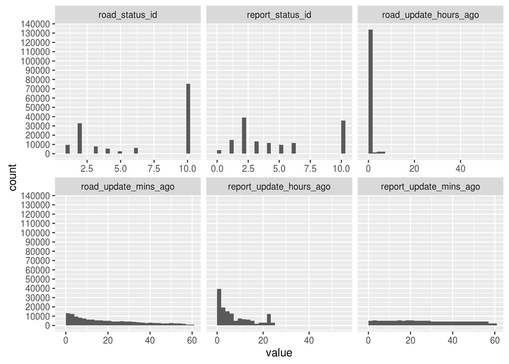

```r
data_plot <- melt(subset(by2olak_data, select=c(road_status_id,report_status_id,road_update_hours_ago,road_update_mins_ago,report_update_hours_ago,report_update_mins_ago)))
ggplot(data_plot,aes(x = value)) + facet_wrap(~variable,scales = "free_x") +
scale_y_continuous(breaks = seq(0, 150000, by = 10000)) + geom_histogram()
```

The road status id and the report status id histograms are having the same trend as the road status id is calculated base on the report status id. For the hours for the road, they are biased towards zero and one as the roads are updated regularly while the hours for reports are still in the first half of the graph but they are scattered unlike in case of roads.

### Automated and Anonymous Reports

In this graph, the data is divided into 2 groups : anonymous and non anonymous reports, then the non-anonymous group is divided into automated and non-automated group.

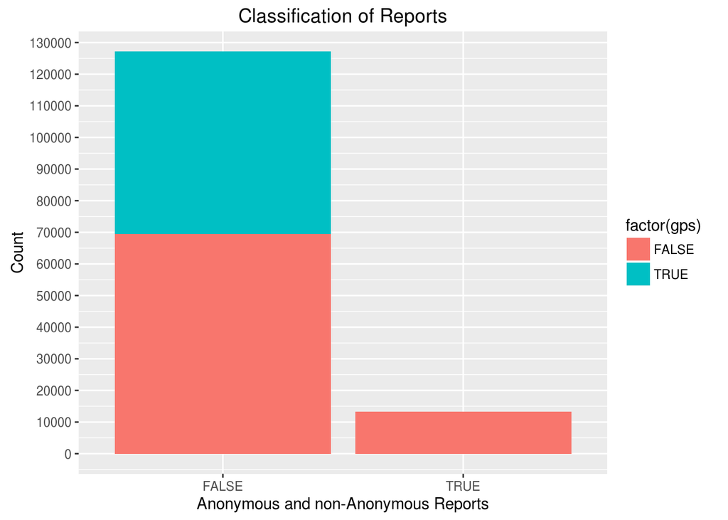

```r
ggplot(by2olak_data, aes(factor(anonymous), fill = factor(gps))) + geom_bar() +
xlab("Anonymous and non-Anonymous Reports") + ylab("Count") + ggtitle("Classification of Reports") +
scale_y_continuous(breaks = seq(0, 150000, by = 10000))
```

Most of the users reports with their usernames not anonymously and also the reports are more likely to be reported by users but there is still a big portion of reports that are automated based on the GPS in the smart phones.

### Speed Box Plot

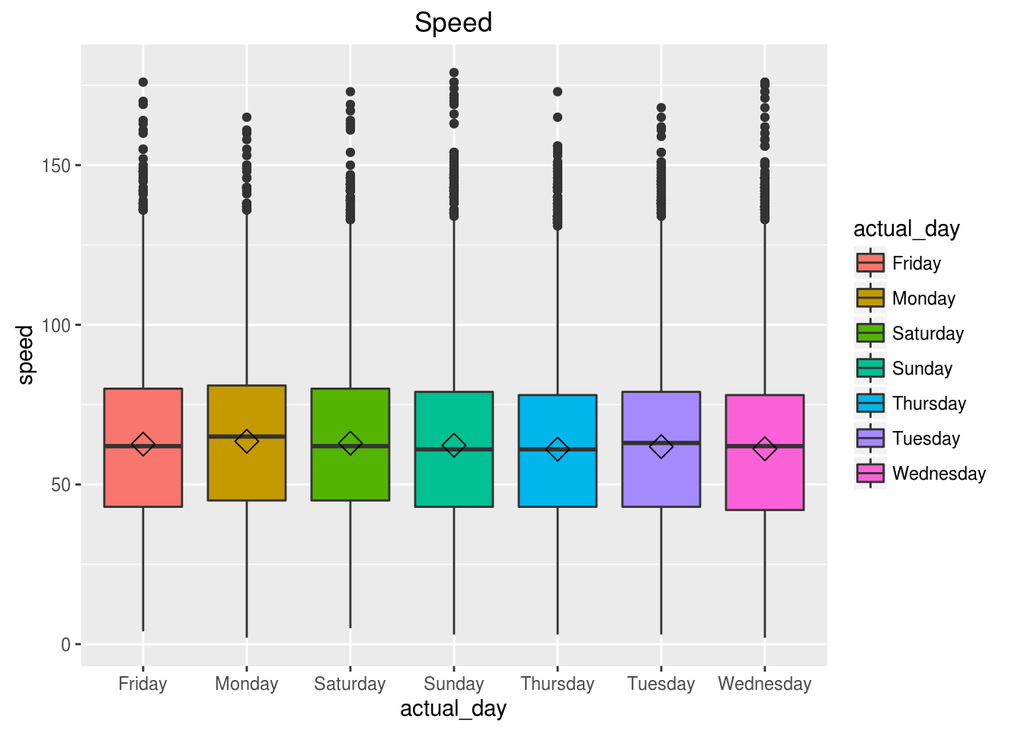

```r
data_plot_speed <- subset(by2olak_data_proper_speed, select=c(actual_day,road_status_id,report_status_id,
road_update_hours_ago,road_update_mins_ago,report_update_hours_ago,report_update_mins_ago,speed))
ggplot(filter(data_plot_speed), aes(x= actual_day, y= speed )) +
     geom_boxplot(aes(fill = actual_day)) +
     stat_summary(fun.y=mean, geom="point", shape=23, size=4) +
     ggtitle("Speed")
```

```r
mean(data_plot_speed$speed)
```

```
## [1] 62.11495
```

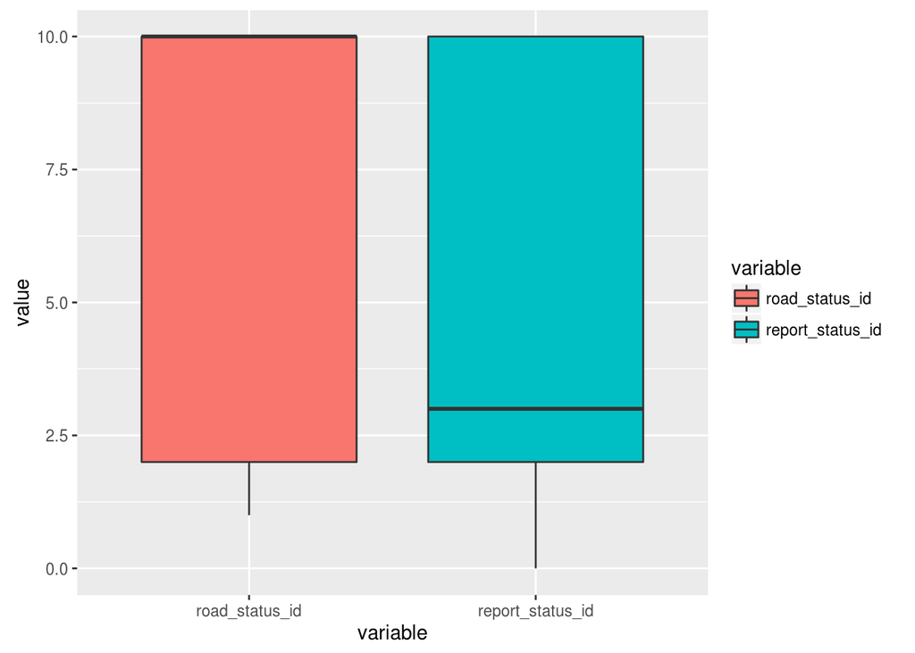

```r
ggplot(data = melt(subset(by2olak_data, select=c(road_status_id, report_status_id))), aes(x=variable, y=value)) + geom_boxplot(aes(fill=variable))
```

In case of the road status, the median is 10 which is equals to the upper quartile, this is due to the fact that there are a lot of questions and inquiries on the road which can be presented by the histograms shown before which show that there are a huge number of road status ids with value 10 which corresponds to “b2olak eh”. In case of report the median is approaching 3 as the data are biased in the first half from 1 to 5 while there are some report status ids with value of 10.

Now let’s do the box plot one more time using the data with status ids from 1 to 5.

Here are the histograms of road status ids and report status ids for the filtered data

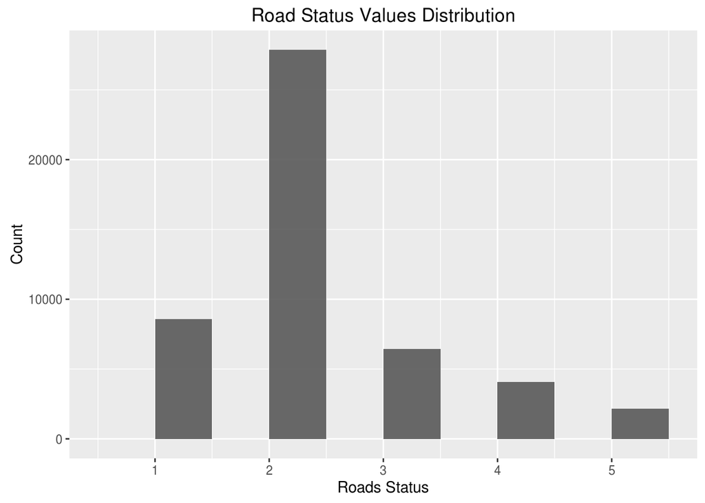

```r
ggplot(by2olak_data_proper_status, aes(road_status_id)) +
     geom_histogram(binwidth=0.5, alpha=0.9) +
     xlab("Roads Status") + ylab("Count") + ggtitle("Road Status Values Distribution")
```

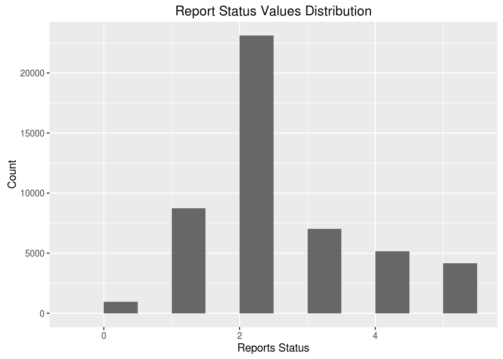

```r
ggplot(by2olak_data_proper_status, aes(report_status_id)) +
     geom_histogram(binwidth=0.5, alpha=0.9) +
     xlab("Reports Status") + ylab("Count") + ggtitle("Report Status Values Distribution")
```

The median is 2 in road and report status id after filtering rows with status ids greater than 5 in both road and report status ids, after taking a look at the 2 above plots, it is clear that most of the status ids are equal 2.

Let’s construct the box plot and see how it reacts to the filtered data

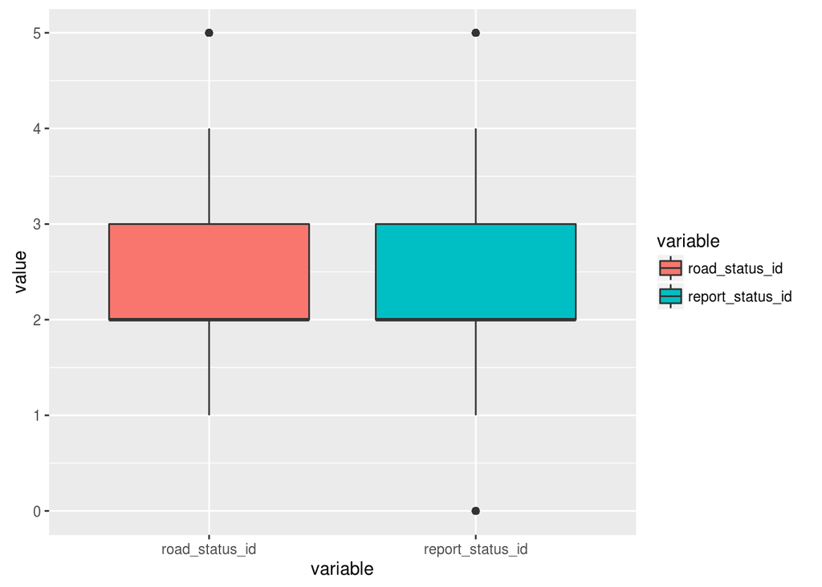

```r
ggplot(data = melt(subset(by2olak_data_proper_status, select=c(road_status_id, report_status_id))), aes(x=variable, y=value)) + geom_boxplot(aes(fill=variable))
```

From the box plot, the ids of value 0 and 5 are considered outliers as they are very few which is supporting the above 2 plots where most of the values are 2 and 3 which consider 5 as outlier, while 0 as well in case of report status id.

### Reports Status by Road Status

Here in this graph, it shows the relation of each report statuses with the road statuses.

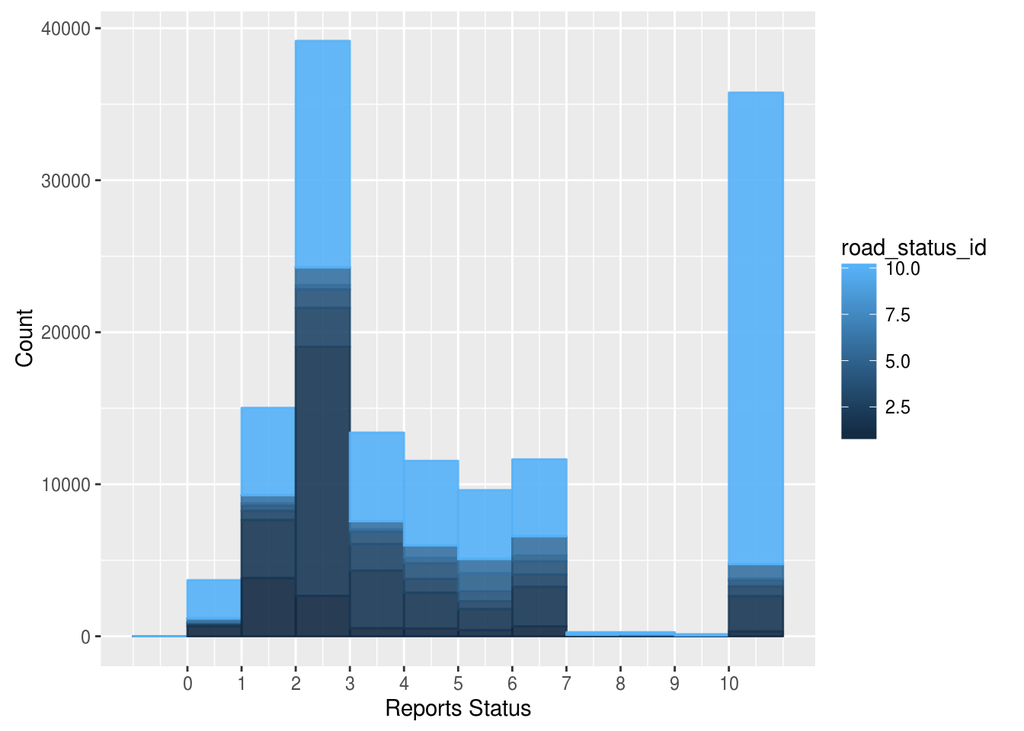

```r
ggplot(by2olak_data, aes(report_status_id, group=road_status_id)) +
    geom_histogram(aes(colour=road_status_id, fill=road_status_id), binwidth=1, alpha=0.9) +
    scale_x_continuous(breaks = seq(0, 10, by = 1)) +
    xlab("Reports Status") + ylab("Count")
```

Here are 2 plots that show the road and report status ids with respect to the day of the update to give an intuition of the distribution of status ids of roads and reports on each day.

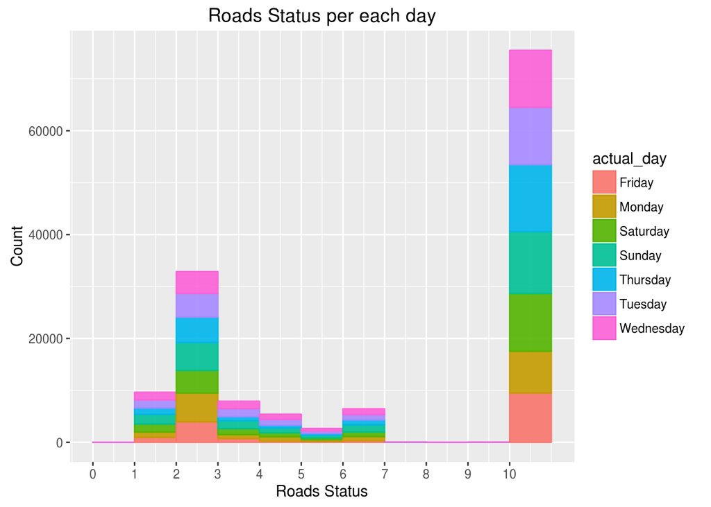

```r
ggplot(by2olak_data, aes(road_status_id, group=actual_day)) +
    geom_histogram(aes(colour=actual_day, fill=actual_day), binwidth=1, alpha=0.9) +
    scale_x_continuous(breaks = seq(0, 10, by = 1)) +
    xlab("Roads Status") + ylab("Count") + ggtitle("Roads Status per each day")
```

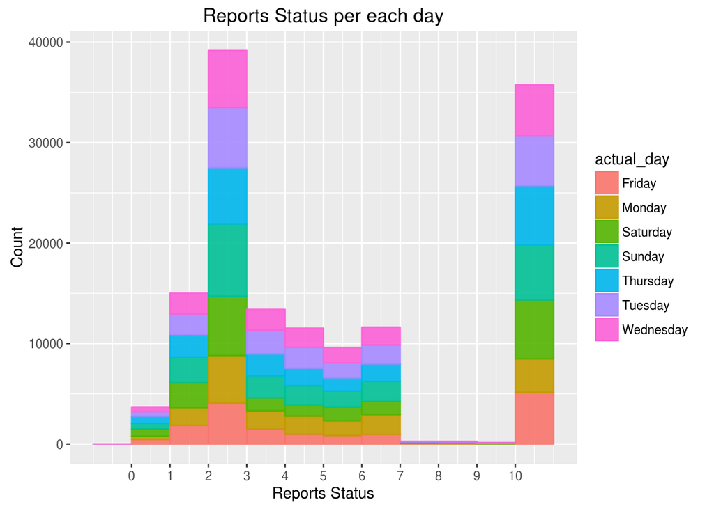

```r
ggplot(by2olak_data, aes(report_status_id, group=actual_day)) +
    geom_histogram(aes(colour=actual_day, fill=actual_day), binwidth=1, alpha=0.9) +
    scale_x_continuous(breaks = seq(0, 10, by = 1)) +
    xlab("Reports Status") + ylab("Count") + ggtitle("Reports Status per each day")
```

The two plots (Reports Status per each day) and (Roads Status per each day) show how road status and report status are correlated as the two plots are having the same behavior .

Now let’s create a box plot for update hours in road and report and see if there are outliers and if so why they exist.

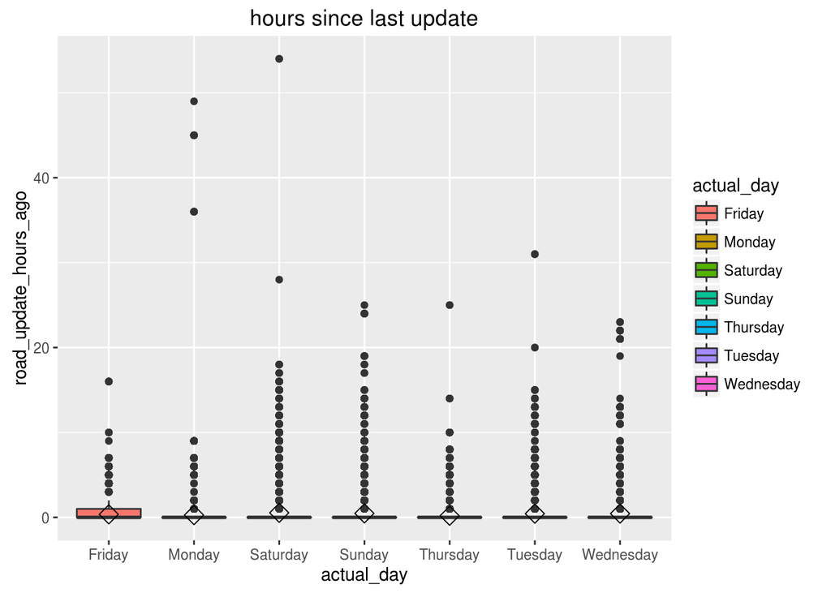

```r
data_plot <- subset(by2olak_data, select=c(actual_day,road_status_id,report_status_id,
road_update_hours_ago,road_update_mins_ago,report_update_hours_ago,report_update_mins_ago,speed))

ggplot(filter(data_plot), aes(x= actual_day, y= road_update_hours_ago )) +
     geom_boxplot(aes(fill = actual_day)) +
     stat_summary(fun.y=mean, geom="point", shape=23, size=4) +
     ggtitle("hours since last update")
```

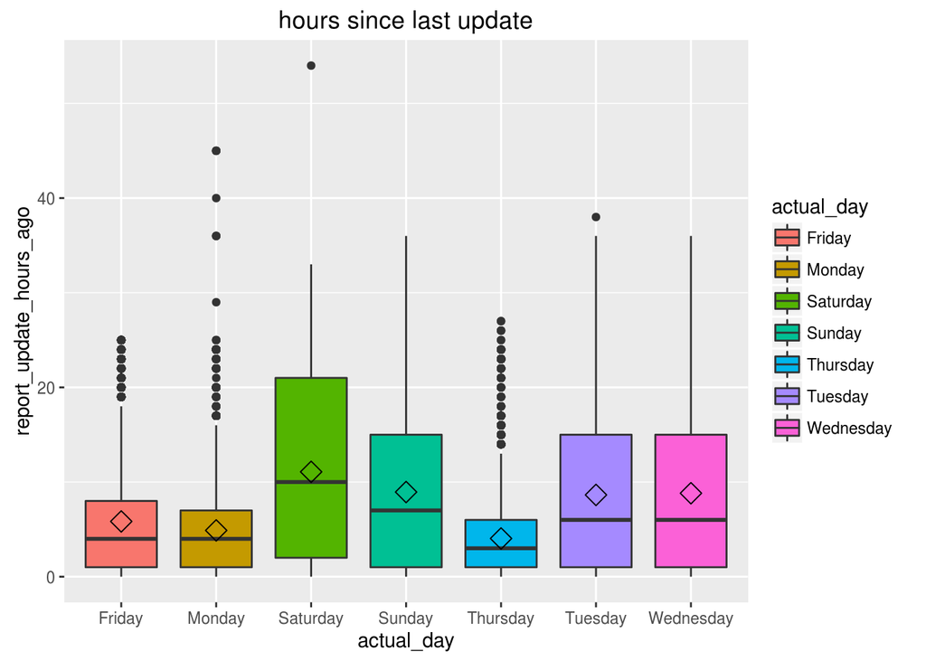

```r
 ggplot(filter(data_plot), aes(x= actual_day, y= report_update_hours_ago )) +
     geom_boxplot(aes(fill = actual_day)) +
     stat_summary(fun.y=mean, geom="point", shape=23, size=4) +
     ggtitle("hours since last update")
```

Since the roads are updated regularly, the mean is nearly equals to 0 which introduces a lot of outliers. In case of reports the data was biased to the first half as we mentioned before which also introduces outliers but less than that of the roads. From the above box plots, it is shown clearly how the data is distributed and how the outliers are found.

## Commentary

# Inferential Data Analysis

## Parameter Inference (confidence intervals)

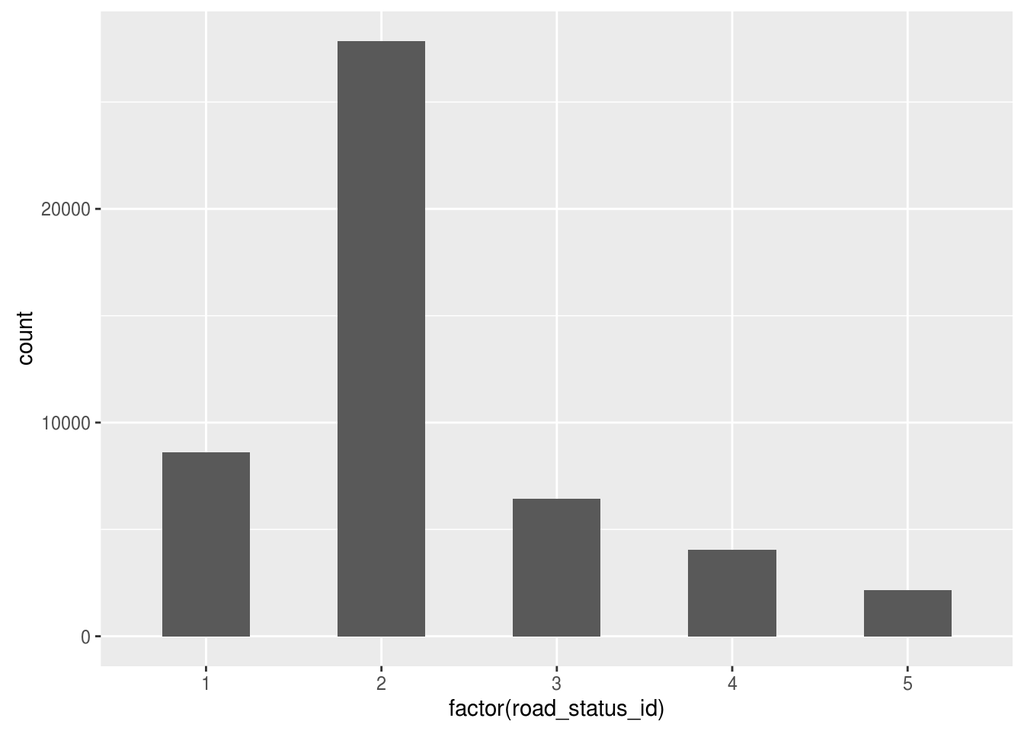

```r
ggplot(by2olak_data_proper_status, aes(factor(road_status_id))) + geom_bar(width=.5)
```

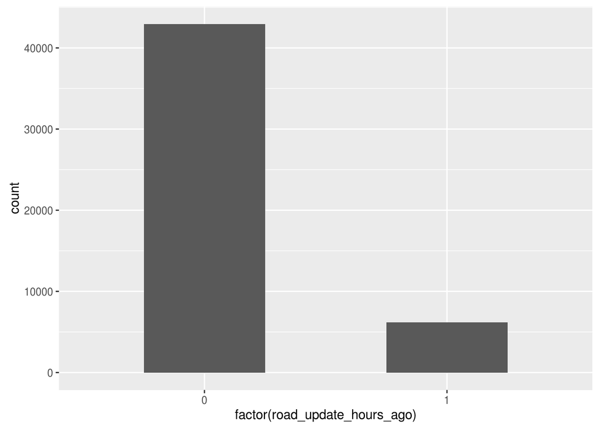

```r
ggplot(by2olak_data_proper_status, aes(factor(road_update_hours_ago))) + geom_bar(width=.5)
```

From the plots, they are not normally distributed, so sample of means is needed to construct a normally distributed data in order to be able to get the confidence intervals of theses columns

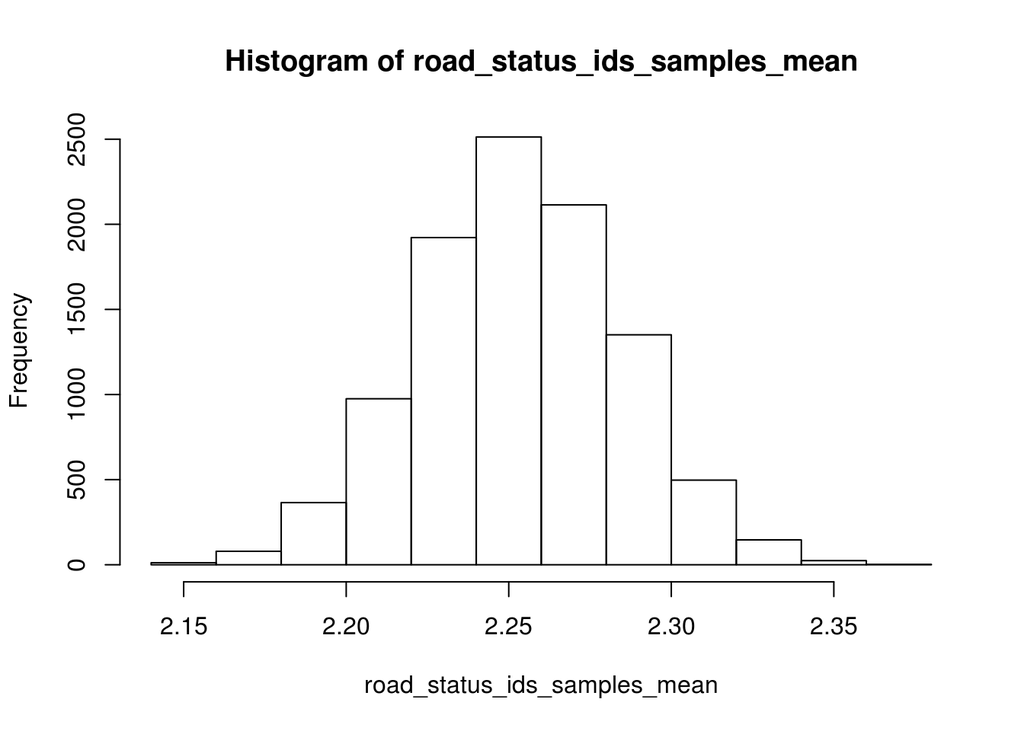

```r
N=10000
road_status_ids_samples_mean=as.vector(N)
for (i in 1:N){
  road_status_ids_samples_mean[i] <- mean(sample(by2olak_data_proper_status$road_status_id, 1000, replace = TRUE))
}
hist(road_status_ids_samples_mean)
```

The distribution of the Sample Mean is normally distributed since the sample size is 1000 which is greater than 36. z-test can be used as it is an appropriate test for such scenario to determine and interpret the 95% and 99% confidence interval of the population mean.

```r
z.test(road_status_ids_samples_mean, sigma.x = sd(road_status_ids_samples_mean), conf.level = 0.99)
```

```
##
##  One-sample z-Test
##
## data:  road_status_ids_samples_mean
## z = 7190.3, p-value < 2.2e-16
## alternative hypothesis: true mean is not equal to 0
## 99 percent confidence interval:
##  2.252998 2.254613
## sample estimates:
## mean of x
##  2.253806
```

Now, to get the 99% confidence interval for the road status id to be 2 is going to be calculated using these 2 equations, one for the upper bound and the other for the lower bound.

#### Lower Bound

```r
qnorm((1-0.99)/2, 2 ,sd(road_status_ids_samples_mean))
```

```
## [1] 1.91926
```

#### Upper Bound

```r
qnorm((0.99/2)+0.5, 2 ,sd(road_status_ids_samples_mean))
```

```
## [1] 2.08074
```

Same for the road update hours + mins ago

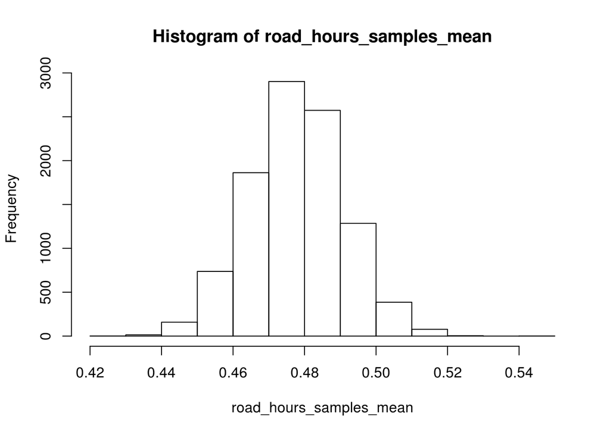

```r
N=10000
road_hours_samples_mean=as.vector(N)
count=1
for (i in 1:N){
  road_hours_samples_mean[count] <- mean(sample(by2olak_data_proper_status$road_update_hours_ago+by2olak_data_proper_status$road_update_mins_ago/60, 1000, replace = TRUE))
  count=count+1
}
hist(road_hours_samples_mean)
```

```r
z.test(road_hours_samples_mean, sigma.x = sd(road_hours_samples_mean), conf.level = 0.99)
```

```
##
##  One-sample z-Test
##
## data:  road_hours_samples_mean
## z = 3608.3, p-value < 2.2e-16
## alternative hypothesis: true mean is not equal to 0
## 99 percent confidence interval:
##  0.4774332 0.4781154
## sample estimates:
## mean of x
## 0.4777743
```

Now, to get the 99% confidence interval for the road update hours to be 1 is going to be calculated using these 2 equations, one for the upper bound and the other for the lower bound as before.

#### Lower Bound

```r
qnorm((1-0.99)/2, 1 ,sd(road_hours_samples_mean))
```

```
## [1] 0.9658935
```

#### Upper Bound

```r
qnorm((0.99/2)+0.5, 1,sd(road_hours_samples_mean))
```

```
## [1] 1.034107
```

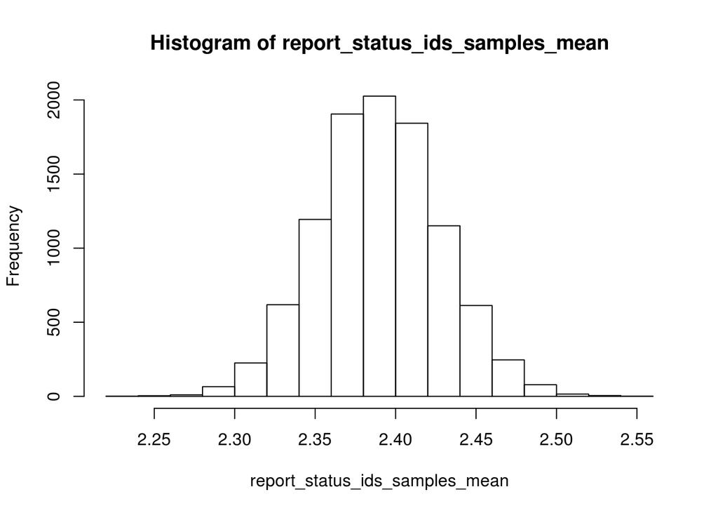

```r
N=10000
report_status_ids_samples_mean=as.vector(N)
count=1
for (i in 1:N){
  report_status_ids_samples_mean[count] <- mean(sample(by2olak_data_proper_status$report_status_id, 1000, replace = TRUE))
  count=count+1
}
hist(report_status_ids_samples_mean)
```

```r
z.test(report_status_ids_samples_mean, sigma.x = sd(report_status_ids_samples_mean), conf.level = 0.95)
```

```
##
##  One-sample z-Test
##
## data:  report_status_ids_samples_mean
## z = 6293, p-value < 2.2e-16
## alternative hypothesis: true mean is not equal to 0
## 95 percent confidence interval:
##  2.389764 2.391253
## sample estimates:
## mean of x
##  2.390509
```

Now, to get the 95% confidence interval for the report status id to be 3 is going to be calculated using these 2 equations, one for the upper bound and the other for the lower bound.

#### Lower Bound

```r
qnorm((1-0.95)/2, 3 ,sd(report_status_ids_samples_mean))
```

```
## [1] 2.925548
```

#### Upper Bound

```r
qnorm((0.95/2)+0.5, 3 ,sd(report_status_ids_samples_mean))
```

```
## [1] 3.074452
```

Same for the report update hours + mins ago

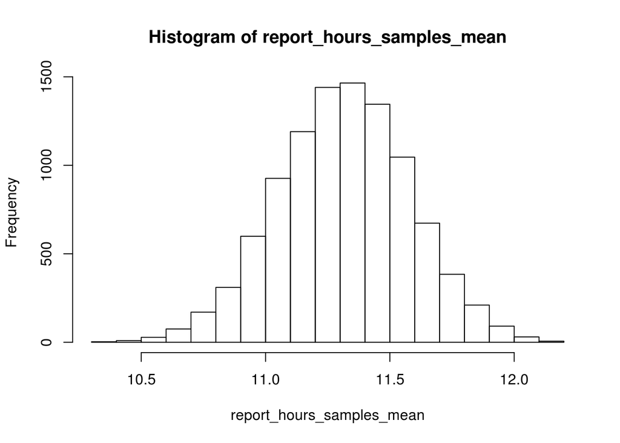

```r
N=10000
report_hours_samples_mean=as.vector(N)
count=1
for (i in 1:N){
  report_hours_samples_mean[count] <- mean(sample(by2olak_data_proper_status$report_update_hours_ago+by2olak_data_proper_status$report_update_mins_ago/60, 1000, replace = TRUE))
  count=count+1
}
hist(report_hours_samples_mean)
```

```r
z.test(report_hours_samples_mean, sigma.x = sd(report_hours_samples_mean), conf.level = 0.95)
```

```
##
##  One-sample z-Test
##
## data:  report_hours_samples_mean
## z = 4261.3, p-value < 2.2e-16
## alternative hypothesis: true mean is not equal to 0
## 95 percent confidence interval:
##  11.30881 11.31922
## sample estimates:
## mean of x
##  11.31402
```

Now, to get the 95% confidence interval for the report update hours to be 10 is going to be calculated using these 2 equations, one for the upper bound and the other for the lower bound as before.

#### Lower Bound

```r
qnorm((1-0.95)/2, 10 ,sd(report_hours_samples_mean))
```

```
## [1] 9.479619
```

#### Upper Bound

```r
qnorm((0.95/2)+0.5, 10,sd(report_hours_samples_mean))
```

```
## [1] 10.52038
```

## Hypothesis Testing (null hypothesis testing)

### 1. Road status id is always updated depending on the closest updated previous reports

So far, there are 2 data frames we are working with: by2olak_data : the cleaned data with all the status ids without filtering by2olak_data_proper_status: the cleaned data with rows having status ids from 1 to 5

The road update hours ago actually depends on the reports update hours ago as it takes the value of update hours ago of the recent report.

Now let’s have a look on both data frames:

```r
kable(as.data.frame(table(by2olak_data$road_update_hours_ago)))
```

| Var1 | Freq |
| --- | --- |
| 0 | 117305 |
| 1 | 16440 |
| 2 | 697 |
| 3 | 756 |
| 4 | 823 |
| 5 | 1394 |
| 6 | 1259 |
| 7 | 884 |
| 8 | 326 |
| 9 | 174 |
| 10 | 104 |
| 11 | 62 |
| 12 | 84 |
| 13 | 54 |
| 14 | 25 |
| 15 | 37 |
| 16 | 17 |
| 17 | 5 |
| 18 | 5 |
| 19 | 6 |
| 20 | 2 |
| 21 | 9 |
| 22 | 6 |
| 23 | 3 |
| 24 | 6 |
| 25 | 3 |
| 28 | 1 |
| 31 | 3 |
| 36 | 5 |
| 45 | 6 |
| 49 | 1 |
| 54 | 2 |

The hours ranges from 0 to 54 hours which is a lot and thus the information on the road would not be correct as it will be outdated.

```r
kable(as.data.frame(table(by2olak_data_proper_status$road_update_hours_ago)))
```

| Var1 | Freq |
| --- | --- |
| 0 | 42956 |
| 1 | 6170 |

The hours have only values of 0 and 1 which is logically correct as the road status should only be updated when the duration of the reports are short.

#### Hypothesis Result

The hypothesis states that road status id is always updated depending on the last updated previous reports, which is not correct. It is only valid when it comes to the basic status ids of by2olak, the status ids that range from 1 to 5, but the others like “b2ollak eh” or “7adsa” can be updated at longer durations.

### 2. The Activity of the application is the same during all day (No rush-hours & day and night are the same)

We discard the roads that are outdated and have old status id as they depend on old outdated reports.

```r
by2olak_data_proper_status_updated <- by2olak_data_proper_status[by2olak_data_proper_status['time_hours'] > 0 & by2olak_data_proper_status['report_update_hours_ago'] <5 ,]
kable(as.data.frame(table(by2olak_data_proper_status_updated$day_night)))
```

| Var1 | Freq |
| --- | --- |
| DAY | 10154 |
| NIGHT | 1137 |

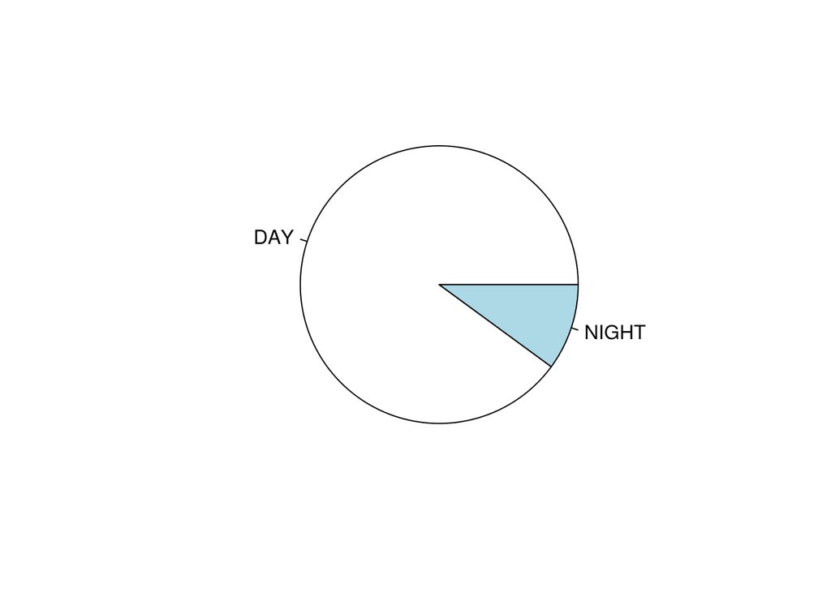

```r
pie(table(by2olak_data_proper_status_updated$day_night))
```

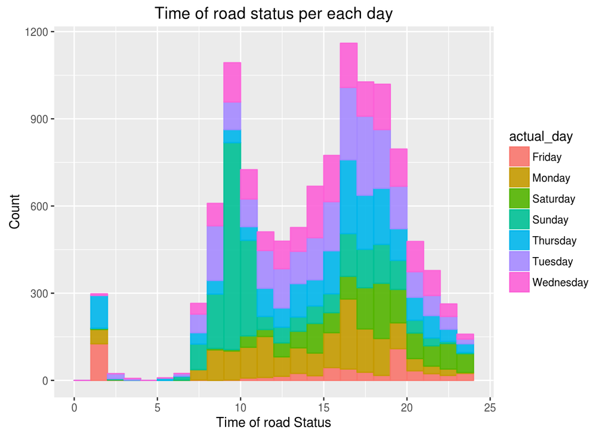

```r
ggplot(by2olak_data_proper_status_updated, aes(time_hours, group=actual_day)) +
    geom_histogram(aes(colour=actual_day, fill=actual_day), binwidth=1, alpha=0.9) +
    xlab("Time of road Status") + ylab("Count") + ggtitle("Time of road status per each day")
```